# R Notebook

This is data preparation so ignore it.

```
# Pylogenetic analysis

{
  require(phytools)
  require(stringr)
}

# ---------------------------------------------------------------------------- #
# prep data
# ---------------------------------------------------------------------------- #
{
  # tree data
  {
    #tree.file <- "data_raw/tree/run1_burn20_mcc_median.tree"
    tree.file <- "data_raw/tree/run5_400M_burnin20_mcc_median.tree"

    tree <- read.nexus(tree.file)
    labels <- tree$tip.label
    labels <- str_replace(labels, "Cubi_tenu", "Cubitermes_tenuiceps")
    labels <- str_replace(labels, "Tern_pall", "Ternicubitermes_pall")
  }

  # tandem data (remove some taxa without phylogeny information)
  {
    d_tandem <- read.csv("data_raw/tree/tandem_info_Mizumoto-etal-2022-PNAS.csv")

    d_tandem <- d_tandem[d_tandem$Species != "convulsionarius",]
    d_tandem <- d_tandem[d_tandem$Genus != "Odontotermes" | (
                           d_tandem$Species != "distans" &
                           d_tandem$Species != "brunneus" &
                           d_tandem$Species != "assmuthi")   ,]
    d_tandem <- d_tandem[d_tandem$Genus != "Nasutitermes" | (
        d_tandem$Species != "nigriceps" &
        d_tandem$Species != "ephratae" &
        d_tandem$Species != "costalis")   ,]
    d_tandem <- d_tandem[d_tandem$Species != "dimorphus",]
    d_tandem <- d_tandem[d_tandem$Species != "unicolor",]
    d_tandem <- d_tandem[d_tandem$Species != "edentatus",]
    d_tandem <- d_tandem[d_tandem$Species != "suspensus",]
    d_tandem <- d_tandem[d_tandem$Species != "bequarerti",]
```

[output cut: 25 more lines]

```
      label_num_list[i_d] <- label_num
    }

    d_tandem$label <- paste(d_tandem$Genus, d_tandem$Species, sep="_")
    d_tandem$label_num <- label_num_list
    d_tandem <- d_tandem[!is.na(d_tandem$label_num),]

    labels[d_tandem$label_num] <- paste(d_tandem$Genus, d_tandem$Species, sep="_")
    tree$tip.label <- labels

    tree_dropped <- drop.tip(tree, labels[!(1:length(labels) %in% d_tandem$label_num)])
    tandem_tree <- ladderize(tree_dropped, right = TRUE)

  }
}
```

```
[1] "Glyptotermes nakajimai_sexual multiple tips exist. use first one."
```

```
# ---------------------------------------------------------------------------- #
```

First, I just do ancestral state reconstruction for tandem (1) or not (0). There could be two models, ER and ARD, where these two achieved very different conclusion. Here is the ER

```
  tandem <- d_tandem$Tandem
  names(tandem) <- paste(d_tandem$Genus, d_tandem$Species, sep="_")
  tandem <- tandem[tandem_tree$tip.label]

  fitER <- ace(tandem, tandem_tree, model="ER",type="discrete")
```

```
  plotTree(tandem_tree,fsize=0.8,ftype="i")
  nodelabels(node=1:tandem_tree$Nnode+Ntip(tandem_tree),
             pie=fitER$lik.anc,piecol=cols,cex=0.5)
```

```
  tiplabels(pie=to.matrix(tandem,sort(unique(tandem))),piecol=cols,cex=0.3)
```

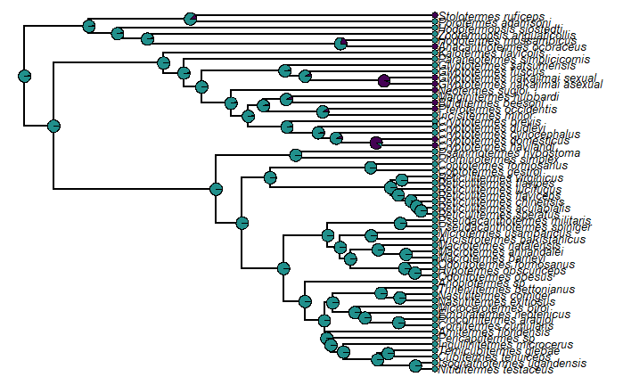

```
NA
```

And this is the ARD

```
  tandem <- d_tandem$Tandem
  names(tandem) <- paste(d_tandem$Genus, d_tandem$Species, sep="_")
  tandem <- tandem[tandem_tree$tip.label]

  fitARD <- ace(tandem, tandem_tree, model="ARD",type="discrete")
```

```
  plotTree(tandem_tree,fsize=0.8,ftype="i")
  nodelabels(node=1:tandem_tree$Nnode+Ntip(tandem_tree),
             pie=fitARD$lik.anc,piecol=cols,cex=0.5)
```

```
  tiplabels(pie=to.matrix(tandem,sort(unique(tandem))),piecol=cols,cex=0.3)
```

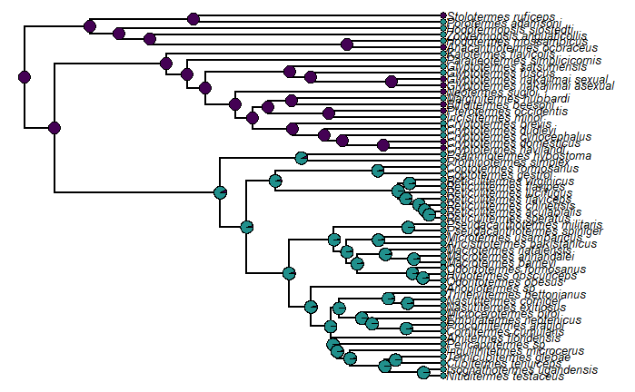

```
NA
```

ARD is better fit.

```
  anova(fitER, fitARD)
```

```
Likelihood Ratio Test Table
  Log lik. Df Df change Resid. Dev Pr(>|Chi|)
1  -21.518  1
2  -18.527  2         1     5.9832    0.01444 *
---
Signif. codes:  0 ‘***’ 0.001 ‘**’ 0.01 ‘*’ 0.05 ‘.’ 0.1 ‘ ’ 1
```

I think this is because we have so many tips in Neoisoptera and all of them are with tandem. So, we need a very strong assumption that once tandem run has evolved, it will be never lost. This can be achived by putting the transition rate 0 with ARD, and thus tandem running evolved multiple times. However, I feel this is unrealistic. And need other models to think about tandem run of Neoisoptera is different from that in other groups.

tandem <- d_tandem$Tandem names(tandem) <- paste(d_tandem$Genus, d_tandem$Species, sep="_") tandem <- tandem[tandem_tree$tip.label]

fitER <- ace(tandem, tandem_tree, model=“ER”,type=“discrete”) fitARD <- ace(tandem, tandem_tree, model=“ARD”,type=“discrete”) anova(fitER, fitARD)

plotTree(tandem_tree,fsize=0.8,ftype=“i”) nodelabels(node=1:tandem_tree$Nnode+Ntip(tandem_tree), pie=fitARD$lik.anc,piecol=cols,cex=0.5) tiplabels(pie=to.matrix(tandem,sort(unique(tandem))),piecol=cols,cex=0.3)

fitER <- fitMk(tandem_tree, tandem, model=“ER”, pi=“fitzjohn”) fitARD <- fitMk(tandem_tree, tandem, model=“ARD”, pi=“fitzjohn”)

fithrmER2<-fitHRM(tandem_tree,tandem,model=“ER”, parallel=T, ncat=c(1,2)) fithrmARD2<-fitHRM(tandem_tree,tandem,model=“ARD”, parallel=T, ncat=c(1,2))

fit_aov <- anova(fitER, fitARD, fithrmER2, fithrmARD2)

cols = viridis(3) anc_parity <- ancr(fithrmARD2,tips=TRUE) plot(anc_parity,args.nodelabels=list(piecol=cols), args.tiplabels=list(piecol=cols))

plot(fithrmARD2)

tandem_data <- data.frame(taxa = names(tandem),tandem) HMM <- corHMM::corHMM(tandem_tree, tandem_data, rate.cat = 2)

RateCat1 <- getStateMat4Dat(tandem_data)$rate.mat # R1 RateCat1 <- equateStateMatPars(RateCat1, c(1:4)) RateCat1

RateCat2 <- getStateMat4Dat(tandem_data)$rate.mat # R2 RateCat2 <- dropStateMatPars(RateCat2, 0) RateCat2 <- dropStateMatPars(RateCat2, 1) RateCat2 <- dropStateMatPars(RateCat2, 2) RateCat2

RateClassMat <- getRateCatMat(2) # RateClassMat <- equateStateMatPars(RateClassMat, c(1,2)) RateClassMat[2,1] <- NA

StateMats <- list(RateCat1, RateCat2) StateMats

FullMat <- getFullMat(StateMats, RateClassMat) FullMat

plotMKmodel(FullMat, rate.cat = 2, display = “row”, text.scale = 0.7)

HMM <- corHMM::corHMM(tandem_tree, tandem_data, rate.cat = 2) HMM_3state_custom <- corHMM(phy = tandem_tree, data = tandem_data, rate.cat = 2, rate.mat = FullMat, node.states = “none”)

MFT_LegendAndRate <- getStateMat4Dat(tandem_data) MFT_LegendAndRate

MFT_R1 <- MFT_LegendAndRate$rate.mat MFT_R2 <- dropStateMatPars(MFT_LegendAndRate$rate.mat, c(1,2)) MFT_ObsStateClasses <- list(MFT_R1, MFT_R2)

MFT_RateClassMat <- getRateCatMat(2) MFT_RateClassMat <- equateStateMatPars(MFT_RateClassMat, 1:2)

MFT_FullMat <- getFullMat(MFT_ObsStateClasses, MFT_RateClassMat)

MFT_res.corHMM <- corHMM(phy = tandem_tree, data = tandem_data, rate.cat = 2, rate.mat = MFT_FullMat, node.states = “none”, root.p = “maddfitz”, get.tip.states = TRUE, )

#MFT_FullMat[4,2] <- 0 #MFT_res.corHMM <- corHMM(phy = tandem_tree, data = tandem_data, # rate.cat = 2, rate.mat = MFT_FullMat, node.states = “none”, root.p = “maddfitz”)

#MFT_FullMat[1,3] <- 0 #MFT_FullMat[3,1] <- 0 #MFT_res.corHMM <- corHMM(phy = tandem_tree, data = tandem_data, # rate.cat = 2, rate.mat = MFT_FullMat, node.states = “none”, root.p = “maddfitz”)

plot(MFT_res.corHMM$phy) phy = MFT_res.corHMM$phy data = MFT_res.corHMM$data model = MFT_res.corHMM$solution model[is.na(model)] <- 0 diag(model) <- -rowSums(model) # run get simmap (can be plotted using phytools) states <- MFT_res.corHMM$states tip.states <- MFT_res.corHMM$tip.states

simmap <- makeSimmap(tree=phy, data=data, model=model, rate.cat=2, nSim=10, nCores=1) phytools::plotSimmap(simmap[[1]], fsize=.5)

anc_parity <- ancr(fitER,tips=TRUE) plot(anc_parity,args.nodelabels=list(piecol=cols), args.tiplabels=list(piecol=cols))

plot(fitARD)

X <- to.matrix(leader, levels(leader)) labs <- row.names(X[apply(X, 1, sum) == 0,]) X[apply(X, 1, sum) == 0, 2:4] <- 1

fit1 <- fitMk(tandem_tree, X, model=“ARD”, pi=“fitzjohn”) fit2 <- fitMk(tandem_tree, X, model=“ER”, pi=“fitzjohn”) fit3 <- fitMk(tandem_tree, X, model=“SYM”, pi=“fitzjohn”)

anova(fit1, fit2, fit3)

ace1 <- ancr(fit3,tips=TRUE) plot(ace1) tips<-sapply(labs,function(x,y) which(y==x),y=tandem_tree$tip.label) add.arrow(tandem_tree,tips,arrl=3,offset=2,lwd=2, col=palette()[4])

#X[“Glyptotermes_satsumensis”,] <- c(0, 1-0.513776, 0.513776) #X[“Glyptotermes_fuscus”,] <- c(0, 1-0.2784785, 0.2784785)

X[X[,1] == 1, ] <- 1 X <- X[,-1] X[apply(X, 1, sum) == 0, ] <- 1

labs <- rownames(X)[apply(X, 1, sum) == 3]

fit1 <- fitMk(tandem_tree, X, model=“ARD”, pi=“fitzjohn”, lik.func=“pruning”, logscale=TRUE) ace1 <- ancr(fit1,tips=TRUE) plot(ace1,args.plotTree=list(direction=“upwards”)) tips<-sapply(labs,function(x,y) which(y==x),y=tandem_tree$tip.label) add.arrow(tandem_tree,tips,arrl=3,offset=2,lwd=2, col=palette()[4])

ordered_model<-matrix(c( 0,1,2, 3,0,4, 5,6,0),3,3, byrow=TRUE, dimnames=list(0:2,0:2)) ordered_model fitER <- fitMk(tandem_tree, tandem, model=“ER”, pi=“fitzjohn”) fitARD <- fitMk(tandem_tree, tandem, model=“ARD”, pi=“fitzjohn”)

fit_aov <- anova(fitER, fitARD) tandem_ancr<-ancr(fit_aov) library(viridis) cols = viridis(2)[1:2] plot(tandem_ancr,args.nodelabels=list(piecol=cols), args.tiplabels=list(piecol=cols),direction=“upwards”)

fitER <- fitgammaMk(tandem_tree, tandem, rand_start=TRUE, model=“ER”) fitARD <- fitgammaMk(tandem_tree, tandem, rand_start=TRUE, model=“ARD”)

fithrmER<-fitHRM(tandem_tree,tandem,model=“ER”, parallel=T) fithrmARD<-fitHRM(tandem_tree,tandem,model=“ARD”, parallel=T) plot(fithrmARD, spacer=0.4, asp=0.5, offset=0.05, signif=4)

cols = viridis(4) anc_parity <- ancr(fithrmER,tips=TRUE) plot(anc_parity,args.nodelabels=list(piecol=cols), args.tiplabels=list(piecol=cols),direction=“upwards”)

anc_parity <- ancr(fithrmARD, tips=TRUE) plot(anc_parity,args.nodelabels=list(piecol=cols), args.tiplabels=list(piecol=cols))

cols = c(0,1) labels <- tandem_tree$tip.label tandem <- tandem[labels] plotTree(tandem_tree, fsize=0.8, ftype=“i”) tiplabels(pie = to.matrix(tandem,sort(unique(tandem))), piecol = cols, cex = 0.3)

fitER <- ace(tandem, tandem_tree, model=“ER”, type=“discrete”) fitARD <- ace(tandem, tandem_tree, model=“ARD”, type=“discrete”)

AIC(fitER, k = 1) AIC(fitARD, k = 2)

nodelabels(node = 1:tandem_tree$Nnode+Ntip(tandem_tree), pie = fitER$lik.anc, piecol = cols, cex=0.5) nodelabels(node = 1:tandem_tree$Nnode+Ntip(tandem_tree), pie = fitARD$lik.anc, piecol = cols, cex=0.5)

library(corHMM) rate.mat <- getRateCatMat(ntraits = 1, nstates = 2, nratecats = 2)

# Fit the model fit <- corHMM(tandem_tree, tandem, rate.cat = 2, node.states = “marginal”)

# Print results print(fit)

cols = 1:3 labels <- tree2$tip.label tandem <- tandem[labels] plotTree(tree2, fsize=0.8, ftype=“i”) tiplabels(pie = to.matrix(tandem, sort(unique(tandem))), piecol = cols, cex = 0.3)

fitER <- ace(tandem, tree2, model=“ER”, type=“discrete”) nodelabels(node = 1:tree2$Nnode+Ntip(tree2), pie = fitER$lik.anc, piecol = cols, cex=0.5)

tandem <- d_tandem$Female names(tandem) <- paste(d_tandem$Genus, d_tandem$Species, sep=“_“) tandem[is.na(tandem)] <- 1

cols = 1:3 labels <- tree2$tip.label tandem <- tandem[labels] plotTree(tree2, fsize=0.8, ftype=“i”) tiplabels(pie = to.matrix(tandem, sort(unique(tandem))), piecol = cols, cex = 0.3)

fitER <- ace(tandem, tree2, model=“ER”, type=“discrete”) nodelabels(node = 1:tree2$Nnode+Ntip(tree2), pie = fitER$lik.anc, piecol = cols, cex=0.5)

tandem <- d_tandem$Male names(tandem) <- paste(d_tandem$Genus, d_tandem$Species, sep=“_“) tandem[is.na(tandem)] <- 1

cols = 1:3 labels <- tree2$tip.label tandem <- tandem[labels] plotTree(tree2, fsize=0.8, ftype=“i”) tiplabels(pie = to.matrix(tandem, sort(unique(tandem))), piecol = cols, cex = 0.3)

fitER <- ace(tandem, tree2, model=“ER”, type=“discrete”) nodelabels(node = 1:tree2$Nnode+Ntip(tree2), pie = fitER$lik.anc, piecol = cols, cex=0.5)

Female <- d_tandem$Female.active names(Female) <- paste(d_tandem$Genus, d_tandem$Species, sep="_") tree3 <- drop.tip(tree2, names(Female)[is.na(Female)]) Female <- Female[!is.na(Female)] Male <- d_tandem$Male.active names(Male) <- paste(d_tandem$Genus, d_tandem$Species, sep=“_“) Male <- Male[!is.na(Male)]

#fit <- fitPagel(tree3, Male, Female)

plot(fit)

cols = 1:2

labels <- tree3$tip.label Female <- Female[labels] Male <- Male[labels] plotTree(tree3, fsize=0.8, ftype="i") tiplabels(pie = to.matrix(Female, sort(unique(Female))), piecol = cols, cex = 0.3) fitER <- ace(Female, tree3, model="ER", type="discrete") nodelabels(node = 1:tree3$Nnode+Ntip(tree3), pie = fitER$lik.anc, piecol = cols, cex=0.5)

plotTree(tree3, fsize=0.8, ftype=“i”) tiplabels(pie = to.matrix(Male, sort(unique(Male))), piecol = cols, cex = 0.3) fitER <- ace(Male, tree3, model=“ER”, type=“discrete”) nodelabels(node = 1:tree3$Nnode+Ntip(tree3), pie = fitER$lik.anc, piecol = cols, cex=0.5)

dtemp <- subset(d_tandem, Tandem == 1)

Female <- d_tandem$Female.active Male <- d_tandem$Male.active

Female[d_tandem$Tandem == 1] Male[d_tandem$Tandem == 1]

cols = 1:3 labels <- tree2$tip.label tandem <- tandem[labels] plotTree(tree2, fsize=0.8, ftype=“i”) tiplabels(pie = to.matrix(tandem, sort(unique(tandem))), piecol = cols, cex = 0.3)

fitER <- ace(tandem, tree2, model=“ER”, type=“discrete”) nodelabels(node = 1:tree2$Nnode+Ntip(tree2), pie = fitER$lik.anc, piecol = cols, cex=0.5)

Female <- d_tandem$Female.active otus <- paste(d_tandem$Genus, d_tandem$Species, sep="_") names(Female) <- otus tree3 <- drop.tip(tree2, names(Female)[is.na(Female) | d_tandem$Tandem == 0]) Female <- Female[!is.na(Female) & d_tandem$Tandem == 1] Male <- d_tandem$Male.active names(Male) <- otus Male <- Male[!is.na(Male) & d_tandem$Tandem == 1]

cols = 1:2

labels <- tree3$tip.label Female <- Female[labels] Male <- Male[labels] plotTree(tree3, fsize=0.8, ftype="i") tiplabels(pie = to.matrix(Female, sort(unique(Female))), piecol = cols, cex = 0.3) fitER <- ace(Female, tree3, model="ER", type="discrete") nodelabels(node = 1:tree3$Nnode+Ntip(tree3), pie = fitER$lik.anc, piecol = cols, cex=0.5)

plotTree(tree3, fsize=0.8, ftype=“i”) tiplabels(pie = to.matrix(Male, sort(unique(Male))), piecol = cols, cex = 0.3) fitER <- ace(Male, tree3, model=“ER”, type=“discrete”) nodelabels(node = 1:tree3$Nnode+Ntip(tree3), pie = fitER$lik.anc, piecol = cols, cex=0.5)